# R Notebook

```r
library(tidyverse)
library(janitor)
library(here)
```

```r
here()
```

```
[1] "/Users/richardmichaelclark/games_data_sales_project/games_data_sales_project"
```

```r
sales_2016 <- read_csv("raw_data/sales-2016-with-ratings.csv")
```

```r
sales_2016
```

| Name | Platform | Year_of_Release | Genre | Publisher | NA_Sales | EU_Sales | JP_Sales | Other_Sales | Global_Sales | Critic_Score | Critic_Count | User_Score | User_Count | Developer | Rating |
| --- | --- | --- | --- | --- | --- | --- | --- | --- | --- | --- | --- | --- | --- | --- | --- |
| Wii Sports | Wii | 2006 | Sports | Nintendo | 41.36 | 28.96 | 3.77 | 8.45 | 82.53 | 76 | 51 | 8 | 322 | Nintendo | E |
| Super Mario Bros. | NES | 1985 | Platform | Nintendo | 29.08 | 3.58 | 6.81 | 0.77 | 40.24 | NA | NA | NA | NA | NA | NA |
| Mario Kart Wii | Wii | 2008 | Racing | Nintendo | 15.68 | 12.76 | 3.79 | 3.29 | 35.52 | 82 | 73 | 8.3 | 709 | Nintendo | E |
| Wii Sports Resort | Wii | 2009 | Sports | Nintendo | 15.61 | 10.93 | 3.28 | 2.95 | 32.77 | 80 | 73 | 8 | 192 | Nintendo | E |
| Pokemon Red/Pokemon Blue | GB | 1996 | Role-Playing | Nintendo | 11.27 | 8.89 | 10.22 | 1.00 | 31.37 | NA | NA | NA | NA | NA | NA |
| Tetris | GB | 1989 | Puzzle | Nintendo | 23.20 | 2.26 | 4.22 | 0.58 | 30.26 | NA | NA | NA | NA | NA | NA |
| New Super Mario Bros. | DS | 2006 | Platform | Nintendo | 11.28 | 9.14 | 6.50 | 2.88 | 29.80 | 89 | 65 | 8.5 | 431 | Nintendo | E |
| Wii Play | Wii | 2006 | Misc | Nintendo | 13.96 | 9.18 | 2.93 | 2.84 | 28.92 | 58 | 41 | 6.6 | 129 | Nintendo | E |
| New Super Mario Bros. Wii | Wii | 2009 | Platform | Nintendo | 14.44 | 6.94 | 4.70 | 2.24 | 28.32 | 87 | 80 | 8.4 | 594 | Nintendo | E |
| Duck Hunt | NES | 1984 | Shooter | Nintendo | 26.93 | 0.63 | 0.28 | 0.47 | 28.31 | NA | NA | NA | NA | NA | NA |

[output cut: 990 more lines]

```r
names(sales_2016)
```

```
 [1] "Name"            "Platform"        "Year_of_Release" "Genre"           "Publisher"
 [6] "NA_Sales"        "EU_Sales"        "JP_Sales"        "Other_Sales"     "Global_Sales"
[11] "Critic_Score"    "Critic_Count"    "User_Score"      "User_Count"      "Developer"
[16] "Rating"
```

I wanted to check all the variable names. They are in capitals so I want to lose the capitals so I will use the clean_names function from janitor package:

```r
sales_clean_2016 <- clean_names(sales_2016)
```

```r
glimpse(sales_clean_2016)
```

```
Rows: 16,719
Columns: 16
$ name            <chr> "Wii Sports", "Super Mario Bros.", "Mario Kart Wii", "Wii Sports Resort", …
$ platform        <chr> "Wii", "NES", "Wii", "Wii", "GB", "GB", "DS", "Wii", "Wii", "NES", "DS", "…
$ year_of_release <chr> "2006", "1985", "2008", "2009", "1996", "1989", "2006", "2006", "2009", "1…
$ genre           <chr> "Sports", "Platform", "Racing", "Sports", "Role-Playing", "Puzzle", "Platf…
$ publisher       <chr> "Nintendo", "Nintendo", "Nintendo", "Nintendo", "Nintendo", "Nintendo", "N…
$ na_sales        <dbl> 41.36, 29.08, 15.68, 15.61, 11.27, 23.20, 11.28, 13.96, 14.44, 26.93, 9.05…
$ eu_sales        <dbl> 28.96, 3.58, 12.76, 10.93, 8.89, 2.26, 9.14, 9.18, 6.94, 0.63, 10.95, 7.47…
$ jp_sales        <dbl> 3.77, 6.81, 3.79, 3.28, 10.22, 4.22, 6.50, 2.93, 4.70, 0.28, 1.93, 4.13, 7…
$ other_sales     <dbl> 8.45, 0.77, 3.29, 2.95, 1.00, 0.58, 2.88, 2.84, 2.24, 0.47, 2.74, 1.90, 0.…
$ global_sales    <dbl> 82.53, 40.24, 35.52, 32.77, 31.37, 30.26, 29.80, 28.92, 28.32, 28.31, 24.6…
$ critic_score    <dbl> 76, NA, 82, 80, NA, NA, 89, 58, 87, NA, NA, 91, NA, 80, 61, 80, 97, 95, NA…
$ critic_count    <dbl> 51, NA, 73, 73, NA, NA, 65, 41, 80, NA, NA, 64, NA, 63, 45, 33, 50, 80, NA…
$ user_score      <chr> "8", NA, "8.3", "8", NA, NA, "8.5", "6.6", "8.4", NA, NA, "8.6", NA, "7.7"…
$ user_count      <dbl> 322, NA, 709, 192, NA, NA, 431, 129, 594, NA, NA, 464, NA, 146, 106, 52, 3…
$ developer       <chr> "Nintendo", NA, "Nintendo", "Nintendo", NA, NA, "Nintendo", "Nintendo", "N…
$ rating          <chr> "E", NA, "E", "E", NA, NA, "E", "E", "E", NA, NA, "E", NA, "E", "E", "E", …
```

O want to check for missing variables and n/a so I do this through summary function.

```r
summary(sales_clean_2016)
```

```
     name             platform         year_of_release       genre            publisher
 Length:16719       Length:16719       Length:16719       Length:16719       Length:16719
 Class :character   Class :character   Class :character   Class :character   Class :character
 Mode  :character   Mode  :character   Mode  :character   Mode  :character   Mode  :character




    na_sales          eu_sales         jp_sales        other_sales        global_sales
 Min.   : 0.0000   Min.   : 0.000   Min.   : 0.0000   Min.   : 0.00000   Min.   : 0.0100
 1st Qu.: 0.0000   1st Qu.: 0.000   1st Qu.: 0.0000   1st Qu.: 0.00000   1st Qu.: 0.0600
 Median : 0.0800   Median : 0.020   Median : 0.0000   Median : 0.01000   Median : 0.1700
 Mean   : 0.2633   Mean   : 0.145   Mean   : 0.0776   Mean   : 0.04733   Mean   : 0.5335
 3rd Qu.: 0.2400   3rd Qu.: 0.110   3rd Qu.: 0.0400   3rd Qu.: 0.03000   3rd Qu.: 0.4700
 Max.   :41.3600   Max.   :28.960   Max.   :10.2200   Max.   :10.57000   Max.   :82.5300

  critic_score    critic_count     user_score          user_count       developer
 Min.   :13.00   Min.   :  3.00   Length:16719       Min.   :    4.0   Length:16719
 1st Qu.:60.00   1st Qu.: 12.00   Class :character   1st Qu.:   10.0   Class :character
 Median :71.00   Median : 21.00   Mode  :character   Median :   24.0   Mode  :character
 Mean   :68.97   Mean   : 26.36                      Mean   :  162.2
 3rd Qu.:79.00   3rd Qu.: 36.00                      3rd Qu.:   81.0
 Max.   :98.00   Max.   :113.00                      Max.   :10665.0
 NA's   :8582    NA's   :8582                        NA's   :9129
    rating
 Length:16719
 Class :character
 Mode  :character
```

Things I note from the summary:

year_of_release is character class which is odd. Is it a relevant variable to answer the questions? I think for plotting time series that it could be so I would want to change the year to an integer.

na_sales is North American sales eu_sales is European jp_sales is Japan other_sales is rest of world global_sales is the sum of all the others

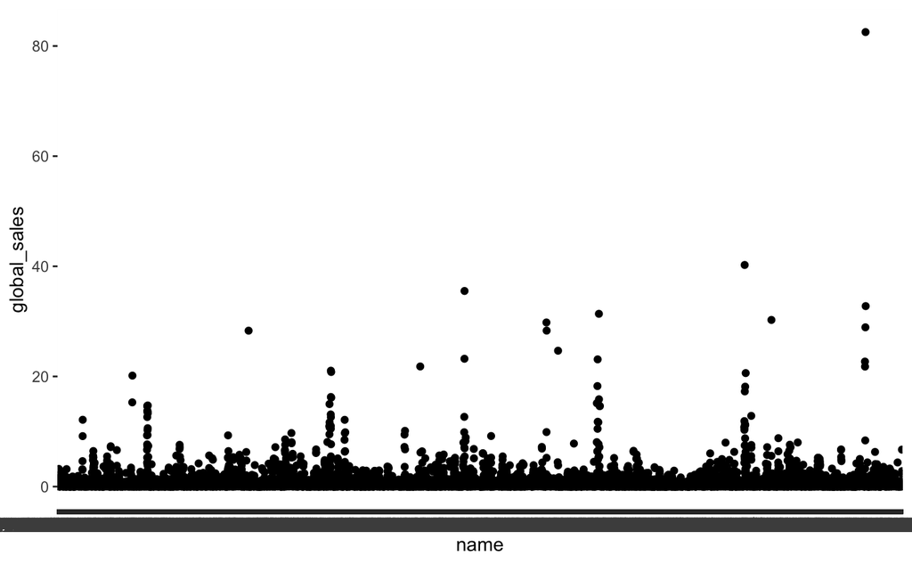

```r
sales_clean_2016 %>%
  ggplot(aes(x = name, y = global_sales)) +
  geom_point()
```

So it would appear that there is one outlier that done much better than the rest. Let’s try and find out who that is:

```r
sales_clean_2016 %>%
  arrange(desc(global_sales))
```

| name | platform | year_of_release | genre | publisher | na_sales | eu_sales | jp_sales | other_sales | global_sales | critic_score | critic_count | user_score | user_count | developer | rating |
| --- | --- | --- | --- | --- | --- | --- | --- | --- | --- | --- | --- | --- | --- | --- | --- |
| Wii Sports | Wii | 2006 | Sports | Nintendo | 41.36 | 28.96 | 3.77 | 8.45 | 82.53 | 76 | 51 | 8 | 322 | Nintendo | E |
| Super Mario Bros. | NES | 1985 | Platform | Nintendo | 29.08 | 3.58 | 6.81 | 0.77 | 40.24 | NA | NA | NA | NA | NA | NA |
| Mario Kart Wii | Wii | 2008 | Racing | Nintendo | 15.68 | 12.76 | 3.79 | 3.29 | 35.52 | 82 | 73 | 8.3 | 709 | Nintendo | E |
| Wii Sports Resort | Wii | 2009 | Sports | Nintendo | 15.61 | 10.93 | 3.28 | 2.95 | 32.77 | 80 | 73 | 8 | 192 | Nintendo | E |
| Pokemon Red/Pokemon Blue | GB | 1996 | Role-Playing | Nintendo | 11.27 | 8.89 | 10.22 | 1.00 | 31.37 | NA | NA | NA | NA | NA | NA |
| Tetris | GB | 1989 | Puzzle | Nintendo | 23.20 | 2.26 | 4.22 | 0.58 | 30.26 | NA | NA | NA | NA | NA | NA |
| New Super Mario Bros. | DS | 2006 | Platform | Nintendo | 11.28 | 9.14 | 6.50 | 2.88 | 29.80 | 89 | 65 | 8.5 | 431 | Nintendo | E |
| Wii Play | Wii | 2006 | Misc | Nintendo | 13.96 | 9.18 | 2.93 | 2.84 | 28.92 | 58 | 41 | 6.6 | 129 | Nintendo | E |
| New Super Mario Bros. Wii | Wii | 2009 | Platform | Nintendo | 14.44 | 6.94 | 4.70 | 2.24 | 28.32 | 87 | 80 | 8.4 | 594 | Nintendo | E |
| Duck Hunt | NES | 1984 | Shooter | Nintendo | 26.93 | 0.63 | 0.28 | 0.47 | 28.31 | NA | NA | NA | NA | NA | NA |

[output cut: 990 more lines]